# ps5.3-Bobby-Deng

Bobby Deng 1663039 ps 5.3

INFO370 Problem Set 5c: Linear Algebra (50pt) Your name: Deadline: Wed, Nov 13th 3pm

## 1 Manipulate images: Flip and stretch (26pt)

In the previous section we rotated the Crazy Hat image. You next task is to flip it, stretch it, and finally combine all these transformations into a single one. If you are not a fan of Crazy Hat, you can also create another image.

## 1.1

1. (8pt) Construct the "flip-x" matrix FX that flips (mirrors) the image on y axis. It should mirror (flip) the x components but leave the y components untouched. Demonstrate this with Crazy Hat. Here is an example where we flip the flipped-1 we used on Tuesday:

```python
import numpy as np
import matplotlib.pyplot as plt
import pandas as pd
```

[output not shown]

[figure not shown]

```python
df = pd.read_csv('crazy-hat.tsv', sep='\t')
plt.plot(df.x, df.y)
#plt.figure(figsize=(12,9))
#plt.xlim(-30, 30)
#plt.ylim(-30, 30)
plt.axis('equal')
```

```
(-17.6, 17.6, -20.0, 24.0)
```

[figure not shown]

```python
a = np.array([df.x, df.y])
Fx = np.array([[-1, 0],[0, 1]])
a_fliped = np.dot(Fx, a)

plt.plot(a_fliped[0], a_fliped[1])
#plt.figure(figsize=(12,9))
#plt.xlim(-30, 30)
#plt.ylim(-30, 30)
plt.axis('equal')
```

```python
print(a)
```

```
[[  0  16 -16   0  -3  -3   2   2 -11  -7  -3   2   6  10  12]
 [ 22 -18 -18  22   7  14   7  14 -10 -17 -10 -17 -10 -17 -13]]
```

**Answer:**

This is the fliped hat along with x axis.

## 1.2

1. (8pt) Create the "stretch-y" matrix S(s). This matrix should stretch (or squish) the y components by amount s while leaving x components untouched. For instance, if s = 2, the object should grow twice as tall, but no wider than the original. Demonstrate it with Crazy Hat Now you have developed three simple tools for image manipulation: ro- tation, flipping and stretching. All these tools can easily be chained. Think like this: original image rotated is just an image (although not the original one). You can just rotate, or flip, or stretch, or do something else with it again. For instance, you can rotate image by a certain angle, stretch it, and rotate it back

**Answer:**

```
The corresponding transition matrix is:
[[1. 0.]
 [0. 2.]]
```

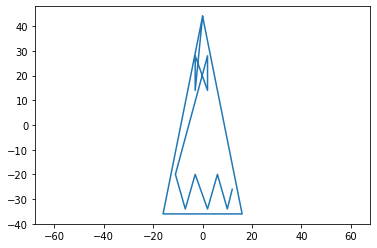

```python
# This is used to stretch and rotate 2d graph,
# x,y is how much and also the direction you want to stretch.
# Example: x = -1 means flip alongside x axis. x=2 means stretch twice alongside x axis.
# alpha is the angle you want to rotate.
# df is the dataset.
def transform_rotate(x, y, alpha, df):
    a = np.array([df.x, df.y])
    Fx = np.array([[x, 0],[0, y]])
    a_fliped = np.dot(Fx, a)

    R = np.array([[np.cos(-alpha*np.pi/180), np.sin(-alpha*np.pi/180)],
              [-np.sin(-alpha*np.pi/180), np.cos(-alpha*np.pi/180)]])

    temp1 = np.dot(np.dot(R.T, Fx), a)
    print('The corresponding transition matrix is: ')
    print(np.dot(R.T, Fx))

    plt.plot(temp1[0], temp1[1])
    plt.axis('equal')


transform_rotate(1, 2, 0, df)
```

## 1.3

```
The corresponding transition matrix is:
[[-0.70710678  1.41421356]
 [ 0.70710678  1.41421356]]
```

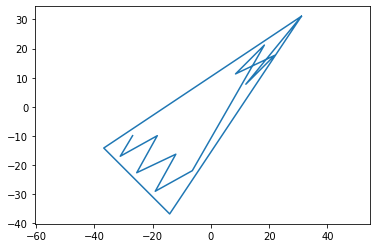

```python
transform_rotate(-1, 2, 45, df)
```

## 1.4

**Answer:**

This is the corresponding transition matrix above.

```
[[-0.70710678  1.41421356]
 [ 0.70710678  1.41421356]]
```

```python
print('Determinant: ', -0.70710678*1.41421356- 1.41421356*0.70710678)
```

```
Determinant:  -1.9999999932878738
```

## 1.5

**Answer:**

- The area became twice as big as before.
1. We can see that the height is stretched twice as much.
2. Also the determinant indictes that the area became twice as big.

## 2.1

```python
A = np.array([[1,0],[0,1]])
```

## 2.2

```python
print('The eigenvalue is: ', np.linalg.eig(A)[0])
```

```
The eigenvalue is:  [1. 1.]
```

```python
print('The eigenvector is: ', np.linalg.eig(A)[1])
```

```
The eigenvector is:  [[1. 0.]
 [0. 1.]]
```

## 2.3

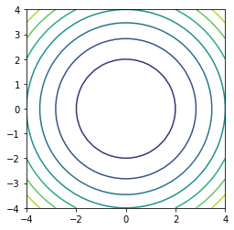

```python
def f(x):
    A = np.array([[1,0],[0,1]])
    return np.dot(x.T, np.dot(A,x))


nGrid = 30
x1 = np.linspace(-4,4,nGrid)
x2 = np.linspace(-4,4,nGrid)
y = np.empty((nGrid, nGrid))
for i in range(len(x1)):
    for j in range(len(x2)):
        y[i,j] = f(np.array([x1[i], x2[j]]))

fig = plt.figure()
ax = fig.add_subplot(111)
a = ax.contour(x1, x2, y)
ax.set_aspect('equal')
plt.show()
```

## 2.4

```
A:
[[1 0]
 [0 1]]
```

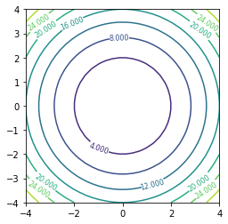

```python
## In this part I made a function to do the stretch and rotation at the
## same time.
## change xx1, yy2 to manipulate the A = I matrix.
def f(x, xx1, yy1):
    A = np.array([[xx1,0],[0,yy1]])
    return np.dot(x.T, np.dot(A,x))

def plotContour(xx1,yy1):
    A = np.array([[xx1,0],[0,yy1]])
    print('A:')
    print(A)
    nGrid = 30
    x1 = np.linspace(-4,4,nGrid)
    x2 = np.linspace(-4,4,nGrid)
    y = np.empty((nGrid, nGrid))
    for i in range(len(x1)):
        for j in range(len(x2)):
            y[i,j] = f(np.array([x1[i], x2[j]]),xx1,yy1)

    fig = plt.figure()
    ax = fig.add_subplot(111)
    a = ax.contour(x1, x2, y)
    ax.clabel(a, inline=1, fontsize=8)
    # ax.set_title('Simplest default with labels')
    ax.set_aspect('equal')
    plt.show()

plotContour(1,1)
```

**Answer:**

- The center is the lowest part of graph. And the outer part is the highest point.

## 2.5

```
A:
[[5 0]
 [0 1]]
```

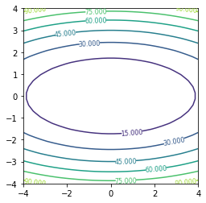

```python
plotContour(5,1)
```

```
A:
[[10  0]
 [ 0  1]]
```

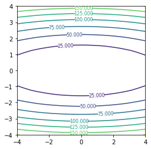

```python
plotContour(10,1)
```

```
A:
[[15  0]
 [ 0  1]]
```

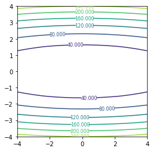

```python
plotContour(15,1)
```

```
A:
[[ 1  0]
 [ 0 10]]
```

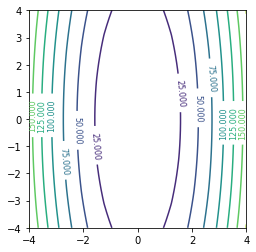

```python
plotContour(1,10)
```

## 3.0

**Answer:**

```
A:
[[  1   0]
 [  0 100]]
```

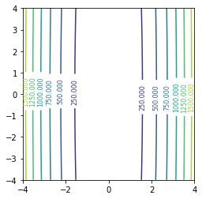

```python
plotContour(1,100)
```

```
A:
[[100   0]
 [  0   1]]
```

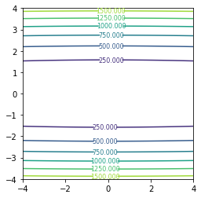

```python
plotContour(100,1)
```

```
A:
[[100   0]
 [  0 100]]
```

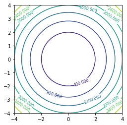

```python
plotContour(100,100)
```